# Is priming consistent across languages? Preliminary findings from the SPAML: Semantic Priming Across Many Languages

Erin M. Buchanan & The Psychological Science Accelerator

# The Psychological Science Accelerator

- The PSA is a CERN for psychological science
- Globally distributed network of researchers with more than 1000 members in 82 countries
- Open science principles and practices
- PSA007: Semantic Priming Across Many Languages

[figure not shown]

# Semantic Priming

- Semantic priming has a rich history in cognitive psychology
- Semantic priming occurs when response latencies are facilitated (faster) for related word-pairs than unrelated word-pairs
- Usually measured with the lexical decision or naming task
- The Semantic Priming Project (Hutchison et al., 2013) provided priming values for 1661 English word-pairs

# Semantic Priming

- **Semantic** priming replicates pretty well
- WEIRD words
- Single language focus or multilingual individuals
- A lack of data sets that are matched on language within one study
- How can we leverage the computational skills found in natural language processing with the open data publications to improve this research?
- Goals of of the SPAML:
  - Assess semantic priming across (at least) 10 languages using matched stimuli
  - Provide a large-scale data set for reuse in linguistics
- Registered Report at *Nature Human Behaviour*

# The Stimuli

- Corpus Text Data: [Open Subtitles Project](http://opus.nlpl.eu/OpenSubtitles-v2018.php)
- Subtitles have shown to be critically useful data sets for word frequency calculation (New et al., 2007; Brysbaert & New, 2009; Keuleers et al., 2010; Cuetos et al., 2012; Van Heuven et al., 2014; Mandera et al., 2015; and more)
- Freely available subtitles in 63 languages for computational analysis
- Approximately 43 languages contain enough data to be usable for these projects

# The Stimuli

- For each language:
  - Collect the top 10,000 most frequent nouns, verbs, adjectives, and adverbs
  - Find the top five most similar words using cosine from subs2vec (van Paridon & Thompson, 2021)
  - Cross-reference this list across languages
  - Pick the most overlapping stimuli limiting repeats and proper names
  - 1000 final pairs
- Important: driven by the language, not English translation

# Nonwords and Translators

- Nonwords are generated with a Wuggy-like algorithm (Keuleers & Brysbaert, 2010)
- Translators check all pairs for proper translation, form, and meaning
- They suggest the appropriate words for retaining meaning between cue-target
- They fix nonwords to ensure they are pronounceable, not too fake
- Dialects are considered and separated when appropriate

# Procedure

- View a simple version: https://psa007.psysciacc.org/
- Overall task:
  - A single stream lexical decision task
  - All words cue-target are judged, cue-target linked by order
- Trials are formatted as:
  - A fixation cross (+) for 500 ms
  - CUE or TARGET in Serif font
  - Lexical decision response (word, nonsense word)
  - Keyboards are WILD
  - 400 pairs = 800 trials

# Power and Study Design

- Power focused on using accuracy in parameter estimation to adequately measure each individual item (see anything by Ken Kelley)
- We simulated using the English Lexicon Project and Semantic Priming Project
  - Minimum: *n* = 50 per target word by condition (related, unrelated)
  - Stopping: *SE* = .09
  - Maximum = *n* = 320
- Adaptive sampling checks and samples pairs once an hour to randomize the study

# Data Provided

- The data will be provided in several forms:
  - Subject/trial level: for every participant
  - Item level: for each individual item, rather than just cue or just concept
  - Priming level: for each related pair compared to the unrelated pair

# Current Data Collection

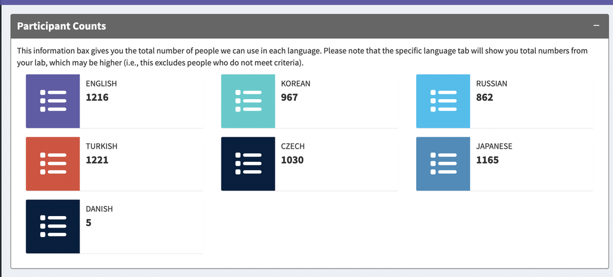

*Big thanks to [ZPID](https://leibniz-psychology.org/en/) and Harrisburg U

# Overall Priming Distribution Results

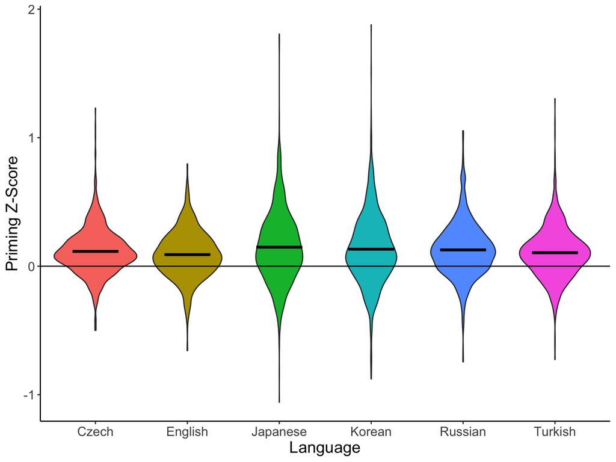

# Overall Priming Comparison

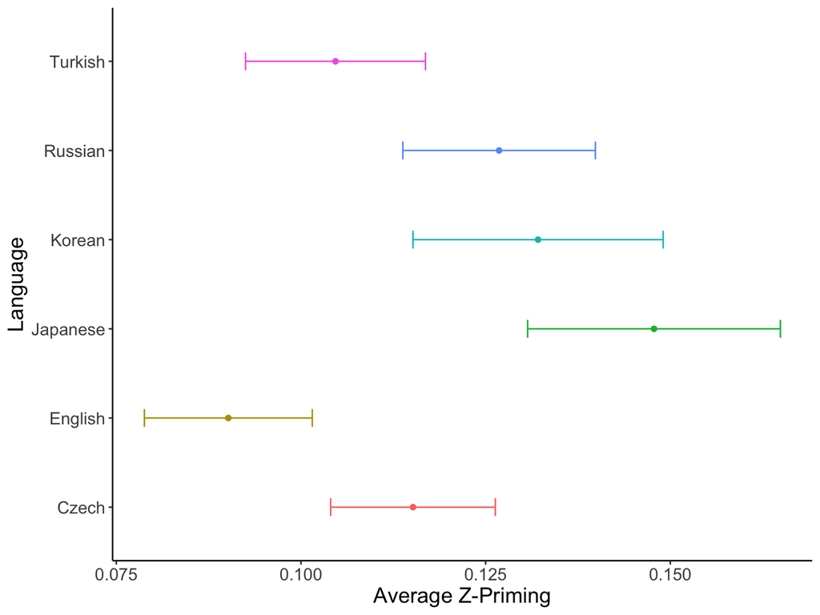

# Individual Item Priming Results

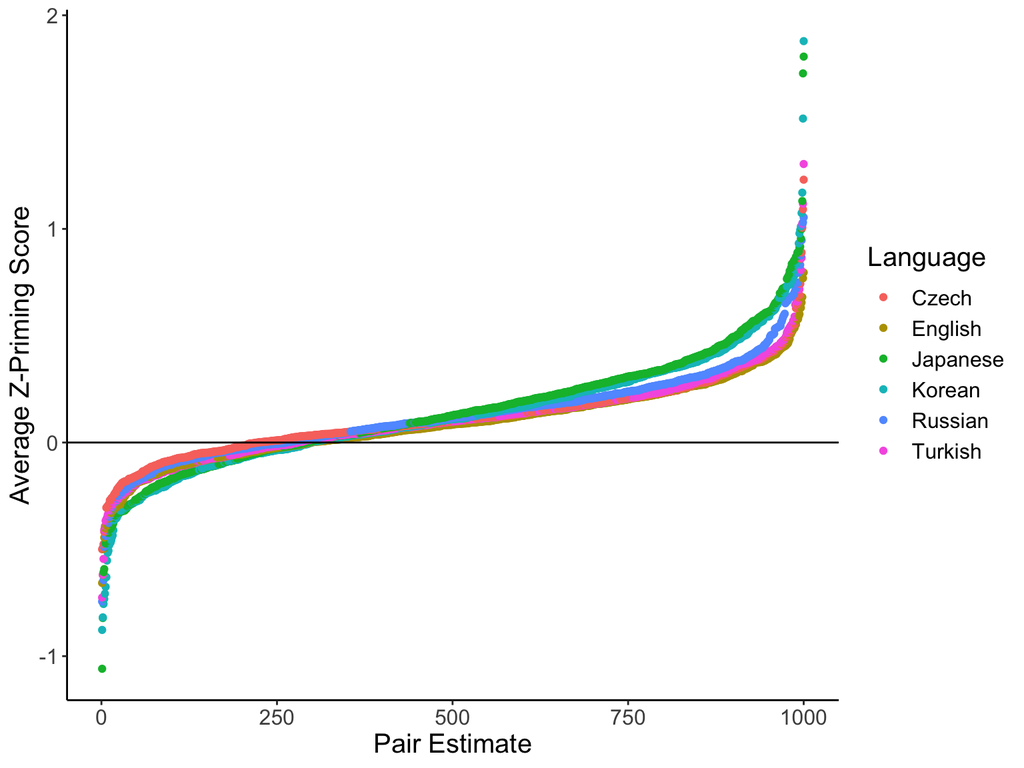

# Final Thoughts

- This work to diversify participants, languages, and researchers represented is aided by big team science approaches
- Priming effects are found across different writing systems
- Variability between languages appears to be approximately .02
- More languages currently underway

# Recruitment and any Questions?

- Thank you for listening!
- We want you - join our team for data collection by contacting me
  - All levels of researchers welcome
  - Authorship is provided for those who meet the collaboration agreement
- All PSA collaborators are listed with their author information online

[figure not shown]